# hw4

Hui Sophie Wang

# Problem 1

## (a)

Name: Hui “Sophie” Wang (1 person project)

## (b)

The goal of this project to find out whether there is correlation between people’s personality and their behavior and activities. If there is, can we predict people’s personality from those behavior and activities? We collected detailed information of subjects’ location/position continuously for about two months. We also have the big five personality score of the subjects.

We have extracted some features from the activity data, and used them in linear regression model. In this project, we want to extract more features, and choose the ones that are not correlated with each other to use in linear regression. Since this problem can also be formed as a classification problem, we can split the personality trait value by median and try logistic regression too. We also want to visualize the data on the campus map in order to get more information from the data.

# Problem 2

## 1.3

There might be a mathematical function that describe the process accurately in theory. But in practice, many factors can affect the process, and there can be various measurements errors. Regression analysis can descirbe the general tendency of one variable to vary with another varialbe, as well as the uncertainty in it, so that errors are accounted for. Therefore, it is suitable to use regression analysis here, and the objection is not valid.

## 1.5

I don’t agree.

Simple linear regression model can be stated as: $Y_i=\beta_0+\beta_1 X_i+\epsilon_i$

On the other hand, $E\{Y_i\}=E\{\beta_0+\beta_1 X_i+\epsilon_i\}=E\{\beta_0+\beta_1 X_i\}+E\{\epsilon_i\}=\beta_0+\beta_1 X_i$

## 1.16

No, it doesn’t.

For linear regression and least squared method to be fully valid, it doesn’t require the distribution of Y to be normal. It is only required that Y has the same constant variance $\sigma^2$ regardless of the value of X, and each Y is uncorrelated to each other, since we assume the error term $\epsilon$ has the same constant variance $\sigma^2$, and uncorrelated to each other.

## 1.18

No, it isn’t true.

$\epsilon$ is the error term of the model, $\epsilon_i=Y_i-(\beta_0+\beta_1 X_i)$, it is the vertical deviation of $Y_i$ from the true regression line, and is unknown.

$e$ is the residual, $e_i=Y_i-(b_0+b_1 X_i)$, it is the vertical deviation of $Y_i$ from our estimated regression line, and is known.

## 1.22

### (a)

```r
X <- c(16, 16, 16, 16, 24, 24, 24, 24,
       32, 32, 32, 32, 40, 40, 40, 40)
Y <- c(199, 205, 196, 200, 218, 220, 215, 223,
       237, 234, 235, 230, 250, 248, 253, 246)

b1 <- sum((X-mean(X))*(Y-mean(Y)))/sum((X-mean(X))*(X-mean(X)))
b1
```

```
## [1] 2.034375
```

```r
b0 <- mean(Y)-mean(X)*b1
b0
```

```
## [1] 168.6
```

$Y_i=2.034375 X_i + 168.6 + \epsilon_i$

Yes, linear regression gives a good fit.

### (b)

When X=40, point estimate of Y is 249.975

### (c)

When X increases by 1 hour, point estimate of the change in mean hardness is 2.034375

## 1.26

### (a)

```r
Y_estimate <- X*b1+b0
residual <- Y - Y_estimate
residual
```

```
##  [1] -2.150  3.850 -5.150 -1.150  0.575  2.575 -2.425  5.575  3.300  0.300
## [11]  1.300 -3.700  0.025 -1.975  3.025 -3.975
```

```r
sum(residual)
```

```
## [1] -3.410605e-13
```

### (b)

```r
sse <- sum((Y-mean(Y))*(Y-mean(Y)))
mse <- sse/(16-2)
mse
```

```
## [1] 388.8527
```

$\sigma$ is expressed in Brinell unit as Y

# Problem 3

```r
library(tidyr, quietly = TRUE)
library(dplyr, quietly = TRUE)
sestates <- read.csv("http://samplecsvs.s3.amazonaws.com/Sacramentorealestatetransactions.csv", header = TRUE, stringsAsFactors = FALSE)
head(sestates)
```

```
##               street       city   zip state beds baths sq__ft        type
## 1       3526 HIGH ST SACRAMENTO 95838    CA    2     1    836 Residential
## 2        51 OMAHA CT SACRAMENTO 95823    CA    3     1   1167 Residential
## 3     2796 BRANCH ST SACRAMENTO 95815    CA    2     1    796 Residential
## 4   2805 JANETTE WAY SACRAMENTO 95815    CA    2     1    852 Residential
## 5    6001 MCMAHON DR SACRAMENTO 95824    CA    2     1    797 Residential
## 6 5828 PEPPERMILL CT SACRAMENTO 95841    CA    3     1   1122       Condo
##                      sale_date price latitude longitude
## 1 Wed May 21 00:00:00 EDT 2008 59222 38.63191 -121.4349
## 2 Wed May 21 00:00:00 EDT 2008 68212 38.47890 -121.4310
## 3 Wed May 21 00:00:00 EDT 2008 68880 38.61830 -121.4438
## 4 Wed May 21 00:00:00 EDT 2008 69307 38.61684 -121.4391
## 5 Wed May 21 00:00:00 EDT 2008 81900 38.51947 -121.4358
## 6 Wed May 21 00:00:00 EDT 2008 89921 38.66260 -121.3278
```

```r
estates <- tbl_df(sestates)
```

## (a)

```r
# replace "sale_date" with "day_week", "month", "day_month"
estates <- estates %>%
  separate(sale_date, c("day_week", "month", "day_month"))
  glimpse(estates)
```

```
## Observations: 985
## Variables: 14
## $ street    (chr) "3526 HIGH ST", "51 OMAHA CT", "2796 BRANCH ST", "28...
## $ city      (chr) "SACRAMENTO", "SACRAMENTO", "SACRAMENTO", "SACRAMENT...
## $ zip       (int) 95838, 95823, 95815, 95815, 95824, 95841, 95842, 958...
## $ state     (chr) "CA", "CA", "CA", "CA", "CA", "CA", "CA", "CA", "CA"...
## $ beds      (int) 2, 3, 2, 2, 2, 3, 3, 3, 2, 3, 3, 3, 1, 3, 2, 2, 2, 2...
## $ baths     (int) 1, 1, 1, 1, 1, 1, 2, 1, 2, 2, 2, 2, 1, 1, 2, 2, 1, 1...
## $ sq__ft    (int) 836, 1167, 796, 852, 797, 1122, 1104, 1177, 941, 114...
## $ type      (chr) "Residential", "Residential", "Residential", "Reside...
## $ day_week  (chr) "Wed", "Wed", "Wed", "Wed", "Wed", "Wed", "Wed", "We...
## $ month     (chr) "May", "May", "May", "May", "May", "May", "May", "Ma...
## $ day_month (chr) "21", "21", "21", "21", "21", "21", "21", "21", "21"...
## $ price     (int) 59222, 68212, 68880, 69307, 81900, 89921, 90895, 910...
## $ latitude  (dbl) 38.63191, 38.47890, 38.61830, 38.61684, 38.51947, 38...
## $ longitude (dbl) -121.4349, -121.4310, -121.4438, -121.4391, -121.435...
```

## (b)

```r
  # the top 10 cities with the most transactions
estates %>%
  group_by(city) %>%
  summarise(n_trans_city = n()) %>%
  arrange(desc(n_trans_city)) %>%
  head(10)
```

```
## Source: local data frame [10 x 2]
##
##               city n_trans_city
##              (chr)        (int)
## 1       SACRAMENTO          439
## 2        ELK GROVE          114
## 3          LINCOLN           72
## 4        ROSEVILLE           48
## 5   CITRUS HEIGHTS           35
## 6         ANTELOPE           33
## 7   RANCHO CORDOVA           28
## 8  EL DORADO HILLS           23
## 9             GALT           21
## 10 NORTH HIGHLANDS           21
```

## (c)

```r
# accumulated number of transactions from May 15 to May 21 in city ELK GROVE
estates %>%
  select(city, month, day_month) %>%
  filter(city=="ELK GROVE", month=="May", day_month>=15 & day_month<=21) %>%
  group_by(month, day_month) %>%
  summarise(n_trans_day = n()) %>%
  arrange(day_month) %>%
  mutate(n_cumtrans_day=cumsum(n_trans_day))
```

```
## Source: local data frame [5 x 4]
## Groups: month [1]
##
##   month day_month n_trans_day n_cumtrans_day
##   (chr)     (chr)       (int)          (int)
## 1   May        15          13             13
## 2   May        16          28             41
## 3   May        19          19             60
## 4   May        20          22             82
## 5   May        21          32            114
```

## (d)

```r
# For each type of house, the highest 3 transaction prices
estates %>%
  select(type, city, price) %>%
  group_by(type) %>%
  arrange(desc(price)) %>%
  top_n(3)
```

```
## Source: local data frame [10 x 3]
## Groups: type [4]
##
##            type            city  price
##           (chr)           (chr)  (int)
## 1         Condo      SACRAMENTO 360000
## 2         Condo       ROSEVILLE 350000
## 3         Condo      GOLD RIVER 300000
## 4  Multi-Family      SACRAMENTO 416767
## 5  Multi-Family      SACRAMENTO 297000
## 6  Multi-Family          AUBURN 285000
## 7   Residential          WILTON 884790
## 8   Residential EL DORADO HILLS 879000
## 9   Residential          LOOMIS 839000
## 10       Unkown SHINGLE SPRINGS 275000
```

## (e)

```r
# For each type of house, the highest 3 transaction prices per sq_ft
summary(estates$sq__ft)
```

```
##    Min. 1st Qu.  Median    Mean 3rd Qu.    Max.
##       0     952    1304    1315    1718    5822
```

```r
estates[estates == 0] <- NA
summary(estates$sq__ft)
```

```
##    Min. 1st Qu.  Median    Mean 3rd Qu.    Max.    NA's
##     484    1144    1418    1591    1851    5822     171
```

```r
estates %>%
  select(type, city, price, sq__ft) %>%
  mutate(price_sq = price / sq__ft) %>%
  group_by(type) %>%
  arrange(desc(price_sq)) %>%
  top_n(3) %>%
  select(type, city, price_sq)
```

```
## Source: local data frame [9 x 3]
## Groups: type [3]
##
##           type       city price_sq
##          (chr)      (chr)    (dbl)
## 1        Condo SACRAMENTO 304.9233
## 2        Condo SACRAMENTO 214.3740
## 3        Condo     AUBURN 207.1713
## 4 Multi-Family     AUBURN 296.8750
## 5 Multi-Family SACRAMENTO 238.9719
## 6 Multi-Family SACRAMENTO 134.2070
## 7  Residential SACRAMENTO 619.6660
## 8  Residential     LOOMIS 516.6256
## 9  Residential SACRAMENTO 459.2652
```

## (f)

```r
# For each type of house in city SACRAMENTO, the number of transactions, average price, and average price per square foot

estates[estates == 0] <- NA
estates %>%
  filter(city=="SACRAMENTO") %>%
  select(type, price, sq__ft) %>%
  mutate(price_sq = price / sq__ft) %>%
  group_by(type) %>%
  summarise(n_trans=n(), avg_price=mean(price), avg_price_sq=mean(price_sq, na.rm=TRUE))
```

```
## Source: local data frame [3 x 4]
##
##           type n_trans avg_price avg_price_sq
##          (chr)   (int)     (dbl)        (dbl)
## 1        Condo      27  137690.7     132.8999
## 2 Multi-Family      10  214189.7     104.5987
## 3  Residential     402  201359.6     137.5226
```

# Problem 4

## (a)

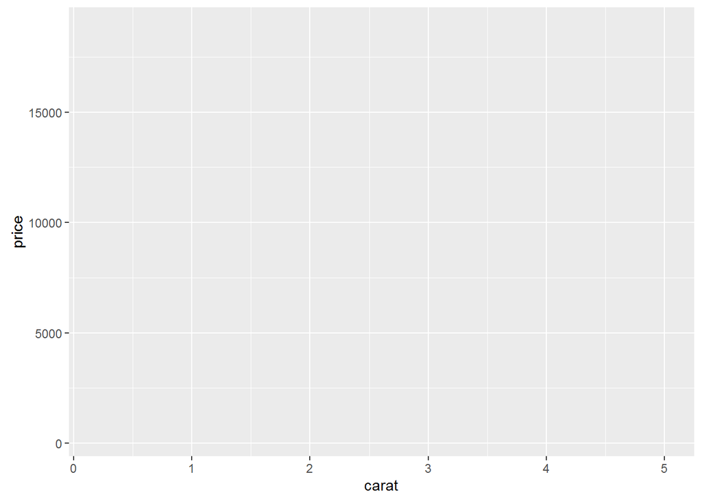

```r
library(ggplot2, quietly = TRUE)
p <- ggplot(diamonds, aes(x=carat, y=price))
p
```

## (b)

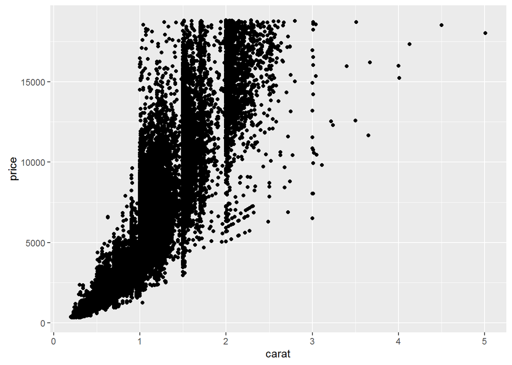

```r
p <- p + geom_point()
p
```

## (c)

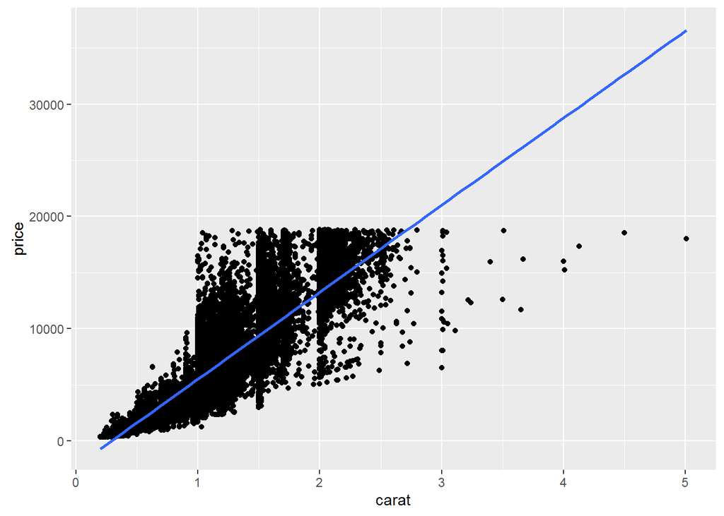

```r
p + geom_smooth(method='lm',formula=y~x)
```

## (d)

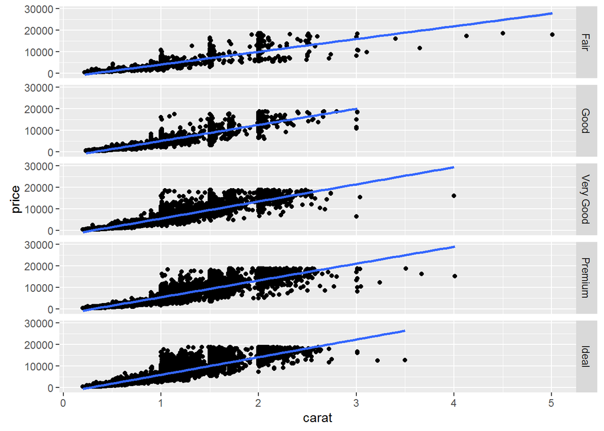

```r
p + facet_grid(cut ~ .) + geom_smooth(method='lm',formula=y~x)
```